# Replicates_Study_Design

Chase Clark

### Purpose:

To justify the number of biological and technical replicates that will be acquired for the R01 IDBac bacterial strain library… where we will be digitizing >8,000 bacterial strains from the ARS strain library housed in the Metcalf lab at UIUC.

### Methods

We chose four strains for this study:

```r
library(ape)
library(here)
library(msaR)
library(dplyr)
library(magrittr)
library(kableExtra)
```

Make reproducible

```r
set.seed(42)
```

Clustal needs to be installed to run this notebook. Clustal can be found here: http://www.clustal.org/omega/

```r
path_to_clustal <- "C:/Users/chase/Downloads/clustal-omega-1.2.2-win64/clustalo"
```

Unfortunately these samples only have 16S rRNA sequences and not MLST or full genome. Below we do a quick and dirty Clustal alignment to visualize the difference in the sequences. Results using the SINA aligner, using default settings at https://www.arb-silva.de/aligner/ can be found in `~/r01_replicates_justification/data/arb-silva.de_2019-12-17_id758783.tgz`

```r
msaR::msaR(here::here("data",
                      "16s_aligment.aln"),
           menu=F,
           overviewbox = F)
```

[interactive chart not shown]

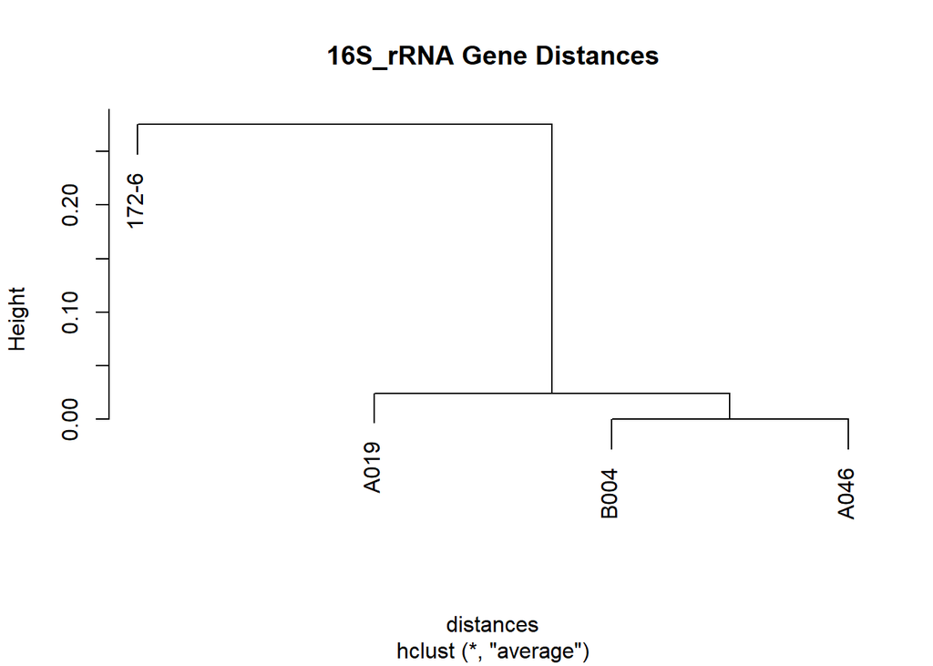

We chose these strains because of the genetic similarity of B004 and A046 and their coming from separate locations, while A019 is less similar than B004 or A046 but from the same location as A046; allowing us to reduce any effect of collection-location of the strain as a potential factor.

Furthermore, B004 and A046 would be designated as the same species based on their 16S-rRNA gene similarity, while A019 would be considered as a separate species of *Streptomyces*

**B004 vs A046**

- Algorithm
- Myers and Miller (Global alignment)
- Length of sequence 1
- 1490 nt
- Length of sequence 2
- 1488 nt
- Similarity
- 1488 / 1488 (100%)

**A046 vs A019**

- Algorithm
- Myers and Miller (Global alignment)
- Length of sequence 1
- 1488 nt
- Length of sequence 2
- 1476 nt
- Similarity
- 1444 / 1473 (98.03%)
- Number of mismatched
- 29 nt

The 16S-rRNA gene comparisons above were analyzed on www.ezbiocloud.net

Yoon, S. H., Ha, S. M., Kwon, S., Lim, J., Kim, Y., Seo, H. and Chun, J. (2017). Introducing EzBioCloud: A taxonomically united database of 16S rRNA and whole genome assemblies. Int J Syst Evol Microbiol. 67:1613-1617.

#### Biological Replicates

On A1-media made with DI-water (no lake water), we grew each of the four strains on 12 separate agar plates.

#### Technical Replicates

For each agar-plate, a **single colony** was applied to four separate MALDI-target-plate-spots.

### Random Acquistion

We used the enclosed R-code (see “Replicates_Study_Design.Rmd”) to generate a randomization of biological and technical replicates across the MALDI plate and across calibration-spots. The only restrictions to the randomization were that each strain had to evenly representd, by either biological, or technical replicates, among each calibration spot.

Samples were spotted around calibration spots as shown in the pattern below:

| Sample | Sample | Sample |
| --- | --- | --- |
| Sample | Calibration | Sample |
| Sample | Sample | Sample |

Biological and technical replicate layout on MALDI target plate:

|  | 1 | 2 | 3 | 4 | 5 | 6 | 7 | 8 | 9 | 10 | 11 | 12 | 13 | 14 | 15 | 16 | 17 | 18 | 19 | 20 | 21 | 22 | 23 | 24 |
| --- | --- | --- | --- | --- | --- | --- | --- | --- | --- | --- | --- | --- | --- | --- | --- | --- | --- | --- | --- | --- | --- | --- | --- | --- |
| A | B004_Bio_12_tech_3 | A019_Bio_9_tech_4 | A046_Bio_3_tech_2 | A019_Bio_7_tech_4 | B004_Bio_3_tech_1 | 172-6_Bio_2_tech_1 | A046_Bio_12_tech_3 | 172-6_Bio_5_tech_1 | 172-6_Bio_4_tech_1 | A046_Bio_12_tech_4 | 172-6_Bio_12_tech_2 | B004_Bio_4_tech_4 | A019_Bio_4_tech_1 | A019_Bio_7_tech_1 | 172-6_Bio_3_tech_4 | NA | NA | NA | NA | NA | NA | NA | NA | NA |
| B | B004_Bio_6_tech_4 | NA | 172-6_Bio_1_tech_1 | B004_Bio_12_tech_4 | NA | A046_Bio_8_tech_1 | A019_Bio_4_tech_4 | NA | A019_Bio_10_tech_2 | A019_Bio_12_tech_3 | NA | 172-6_Bio_12_tech_3 | B004_Bio_5_tech_3 | NA | B004_Bio_1_tech_2 | NA | NA | NA | NA | NA | NA | NA | NA | NA |
| C | A046_Bio_7_tech_1 | 172-6_Bio_10_tech_1 | A019_Bio_5_tech_2 | A046_Bio_11_tech_4 | 172-6_Bio_11_tech_3 | A019_Bio_8_tech_3 | B004_Bio_8_tech_4 | B004_Bio_10_tech_1 | A046_Bio_8_tech_4 | A046_Bio_2_tech_2 | A019_Bio_3_tech_3 | B004_Bio_11_tech_1 | A046_Bio_10_tech_2 | A046_Bio_11_tech_1 | 172-6_Bio_7_tech_4 | NA | NA | NA | NA | NA | NA | NA | NA | NA |
| D | A046_Bio_10_tech_3 | 172-6_Bio_10_tech_2 | B004_Bio_1_tech_3 | A019_Bio_2_tech_1 | A046_Bio_1_tech_2 | B004_Bio_4_tech_1 | 172-6_Bio_8_tech_1 | A019_Bio_3_tech_4 | B004_Bio_5_tech_4 | A019_Bio_9_tech_2 | B004_Bio_12_tech_2 | A046_Bio_5_tech_1 | 172-6_Bio_3_tech_3 | B004_Bio_1_tech_1 | A046_Bio_7_tech_4 | NA | NA | NA | NA | NA | NA | NA | NA | NA |
| E | B004_Bio_7_tech_3 | NA | 172-6_Bio_2_tech_4 | 172-6_Bio_1_tech_3 | NA | A019_Bio_3_tech_2 | A019_Bio_12_tech_2 | NA | 172-6_Bio_10_tech_4 | A046_Bio_9_tech_2 | NA | 172-6_Bio_6_tech_3 | 172-6_Bio_6_tech_2 | NA | A019_Bio_8_tech_1 | NA | NA | NA | NA | NA | NA | NA | NA | NA |
| F | A019_Bio_12_tech_4 | A046_Bio_7_tech_3 | A019_Bio_6_tech_1 | A046_Bio_6_tech_4 | 172-6_Bio_1_tech_4 | B004_Bio_11_tech_3 | A046_Bio_8_tech_3 | A046_Bio_5_tech_3 | B004_Bio_10_tech_2 | A019_Bio_11_tech_3 | 172-6_Bio_2_tech_2 | B004_Bio_7_tech_1 | A046_Bio_4_tech_4 | B004_Bio_6_tech_2 | A019_Bio_12_tech_1 | NA | NA | NA | NA | NA | NA | NA | NA | NA |
| G | 172-6_Bio_12_tech_1 | A019_Bio_10_tech_4 | A046_Bio_10_tech_4 | 172-6_Bio_5_tech_2 | A019_Bio_11_tech_2 | 172-6_Bio_11_tech_1 | 172-6_Bio_8_tech_2 | A046_Bio_3_tech_3 | A046_Bio_12_tech_1 | B004_Bio_6_tech_3 | A019_Bio_2_tech_2 | A046_Bio_2_tech_3 | 172-6_Bio_11_tech_4 | B004_Bio_11_tech_4 | A019_Bio_4_tech_2 | NA | NA | NA | NA | NA | NA | NA | NA | NA |
| H | A046_Bio_8_tech_2 | NA | B004_Bio_6_tech_1 | A046_Bio_4_tech_1 | NA | A019_Bio_5_tech_4 | 172-6_Bio_4_tech_4 | NA | A019_Bio_6_tech_2 | A019_Bio_5_tech_1 | NA | 172-6_Bio_7_tech_1 | A046_Bio_4_tech_3 | NA | A019_Bio_3_tech_1 | NA | NA | NA | NA | NA | NA | NA | NA | NA |
| I | 172-6_Bio_7_tech_3 | B004_Bio_2_tech_2 | A019_Bio_9_tech_1 | B004_Bio_10_tech_3 | A046_Bio_7_tech_2 | B004_Bio_2_tech_4 | B004_Bio_7_tech_2 | B004_Bio_3_tech_4 | A019_Bio_1_tech_1 | 172-6_Bio_1_tech_2 | A046_Bio_6_tech_2 | B004_Bio_8_tech_3 | B004_Bio_12_tech_1 | A046_Bio_3_tech_1 | 172-6_Bio_4_tech_3 | NA | NA | NA | NA | NA | NA | NA | NA | NA |
| J | A046_Bio_1_tech_3 | B004_Bio_9_tech_3 | 172-6_Bio_8_tech_3 | A019_Bio_9_tech_3 | 172-6_Bio_8_tech_4 | 172-6_Bio_11_tech_2 | 172-6_Bio_5_tech_4 | A046_Bio_5_tech_4 | B004_Bio_11_tech_2 | A019_Bio_11_tech_4 | 172-6_Bio_9_tech_4 | B004_Bio_8_tech_1 | 172-6_Bio_7_tech_2 | B004_Bio_3_tech_3 | A046_Bio_9_tech_1 | NA | NA | NA | NA | NA | NA | NA | NA | NA |
| K | 172-6_Bio_10_tech_3 | NA | B004_Bio_5_tech_1 | A019_Bio_6_tech_3 | NA | A046_Bio_1_tech_4 | A019_Bio_4_tech_3 | NA | A046_Bio_5_tech_2 | A046_Bio_2_tech_4 | NA | B004_Bio_5_tech_2 | 172-6_Bio_9_tech_3 | NA | A019_Bio_8_tech_2 | NA | NA | NA | NA | NA | NA | NA | NA | NA |
| L | A019_Bio_7_tech_2 | A019_Bio_10_tech_1 | A046_Bio_12_tech_2 | A046_Bio_6_tech_3 | B004_Bio_3_tech_2 | B004_Bio_7_tech_4 | 172-6_Bio_9_tech_2 | A019_Bio_1_tech_2 | B004_Bio_9_tech_4 | A046_Bio_11_tech_2 | 172-6_Bio_3_tech_1 | A019_Bio_11_tech_1 | A019_Bio_2_tech_3 | B004_Bio_8_tech_2 | A046_Bio_10_tech_1 | NA | NA | NA | NA | NA | NA | NA | NA | NA |
| M | A019_Bio_5_tech_3 | A046_Bio_2_tech_1 | B004_Bio_9_tech_2 | A019_Bio_1_tech_4 | B004_Bio_10_tech_4 | B004_Bio_2_tech_1 | A046_Bio_9_tech_3 | B004_Bio_4_tech_2 | B004_Bio_9_tech_1 | A046_Bio_6_tech_1 | B004_Bio_1_tech_4 | A019_Bio_1_tech_3 | NA | NA | NA | NA | NA | NA | NA | NA | NA | NA | NA | NA |
| N | 172-6_Bio_3_tech_2 | NA | 172-6_Bio_6_tech_4 | 172-6_Bio_4_tech_2 | NA | A046_Bio_4_tech_2 | A046_Bio_3_tech_4 | NA | 172-6_Bio_12_tech_4 | 172-6_Bio_2_tech_3 | NA | A046_Bio_1_tech_1 | NA | NA | NA | NA | NA | NA | NA | NA | NA | NA | NA | NA |
| O | B004_Bio_2_tech_3 | A046_Bio_11_tech_3 | A019_Bio_6_tech_4 | 172-6_Bio_6_tech_1 | A046_Bio_9_tech_4 | A019_Bio_8_tech_4 | A019_Bio_10_tech_3 | 172-6_Bio_9_tech_1 | A019_Bio_7_tech_3 | 172-6_Bio_5_tech_3 | B004_Bio_4_tech_3 | A019_Bio_2_tech_4 | NA | NA | NA | NA | NA | NA | NA | NA | NA | NA | NA | NA |
| P | NA | NA | NA | NA | NA | NA | NA | NA | NA | NA | NA | NA | NA | NA | NA | NA | NA | NA | NA | NA | NA | NA | NA | NA |

List the samples and locations

[output not shown]

[output cut: 88 more lines]

```
##
## $B004_5
## [1] "M-3"  "L-9"  "G-13" "N-13"
##
## $B004_6
## [1] "B-1"  "J-3"  "A-11" "D-15"
##
## $B004_7
## [1] "E-1"  "B-7"  "O-7"  "B-13"
##
## $B004_8
## [1] "I-7"  "E-13" "F-13" "J-15"
##
## $B004_9
## [1] "K-2"  "O-3"  "E-10" "F-10"
```